# Scrolling, Ads, and Algorithms

## So I opened my phone… and guess what I saw?

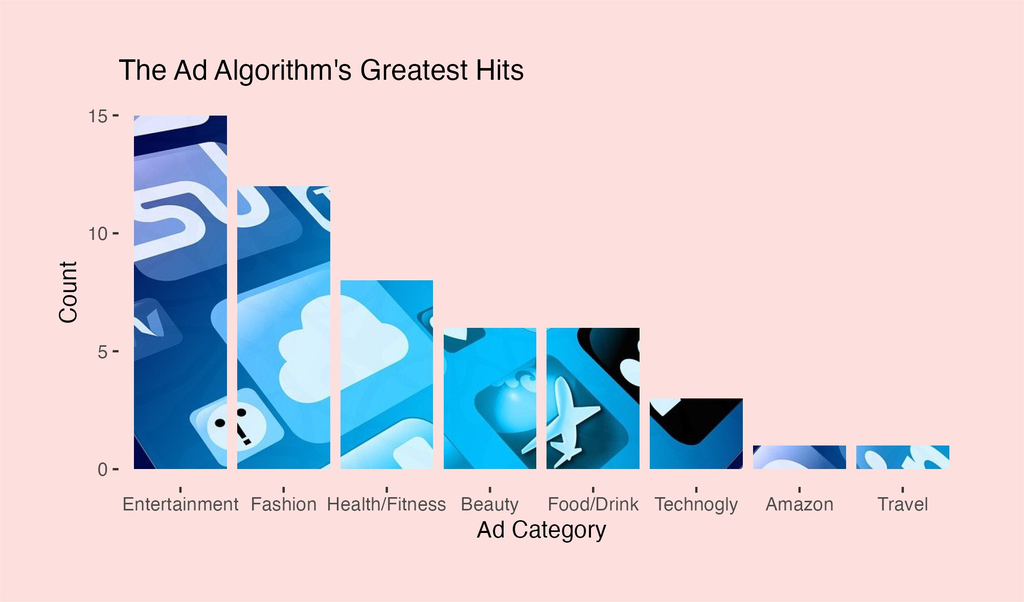

When I open a social media app and start scrolling, the first thing I usually see is an ad — not from a friend, but from a brand or channnel. And based on the data I logged, the algorithm clearly has favourites.

Most first ads I encountered were for **entertainment and fashion**. These categories consistently appeared at the top of the feed, suggesting they’re being prioritised either because of what I engage with, or because they perform well with others in my demographic. So we now know what kinds of ads pop up first, but lets see if **they are actually relevant to me?**

## Is the algorithm stalking me… or just guessing?

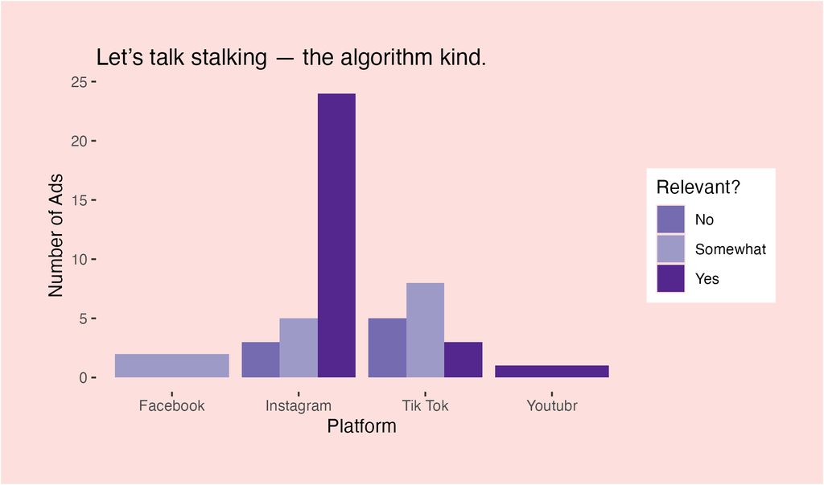

Ad relevance

This plot shows which platforms had ads that felt the most “relevant” to my interests. Unsurprisingly, **Instagram dominates**, with most of its ads being tagged as relevant by me. That’s either impressive targeting or slightly scary. TikTok, on the other hand, had more “somewhat” relevant ads, which might reflect a more generalised feed or broader ad pool. The algorithm knows what I like, especially on Instagram. But relevance isn’t evenly distributed, and not every platform gets me.

## When are the ads hitting hardest?

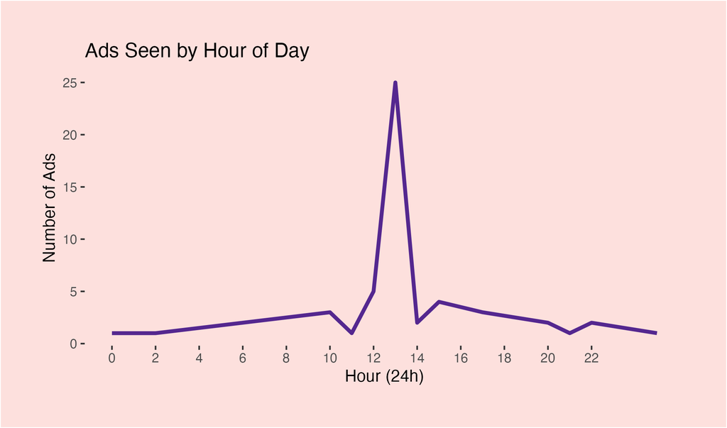

Which time of the day had ads

Here’s when I was hit with the most ads. Throughout the day, things were pretty balanced — until around **1 PM**, when there was a noticeable spike.

Maybe that’s lunchtime scrolling, maybe that’s just me being bored. Either way, platforms seem to push ads when I’m most likely to scroll.

## How long do I stay trapped in the scroll?!

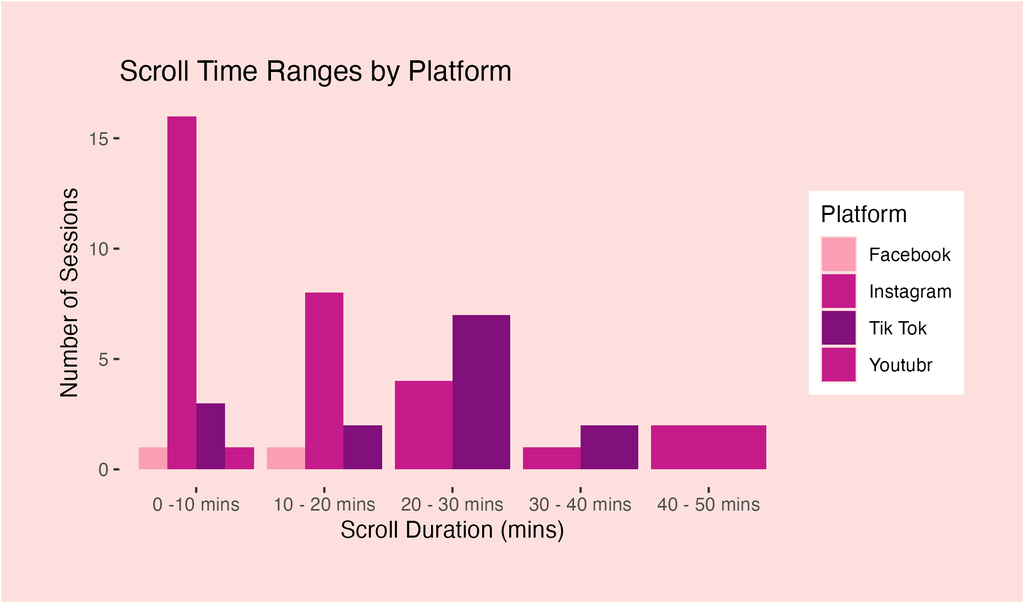

Scroll Time Ranges

Some scrolls last two minutes. Others… not so much.

This plot shows how long I stayed on each platform durring each scroll session recorded. Instagram? Quick check-ins — under 10 minutes. TikTok? That’s where time disappears. Most of my longer sessions were there, between 20–30 minutes.

It’s interesting how different platforms pull me in for different lengths of time. Not every app is equally addictive — but they all know how to keep me looking just long enough to drop another ad.

## So what did I learn?

[figure not shown]

This scroll diary taught me that ads aren’t random. Platforms carefully decide *what* I see, *when* I see it, and *how long* I stay. Some are better at relevance, some at attention-grabbing, and some just keep me there longer than I mean to be.